# **Data Exploration e Preprocessing**

Osserviamo anche il Satisfaction Score. Questo darà informazioni circa la percentuale di soddisfazione dei clienti.

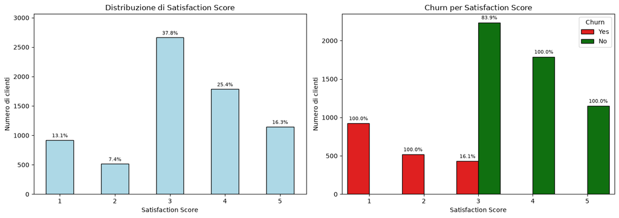

```python
score_order = [1, 2, 3, 4, 5]

score_counts = merged_df['Satisfaction Score'].value_counts().reindex(score_order)
total_scores = score_counts.sum()

palette_churn = {'Yes': 'red', 'No': 'green'}

fig, axes = plt.subplots(1, 2, figsize=(14, 5))

bars_left = axes[0].bar(
    [str(s) for s in score_counts.index],
    score_counts.values,
    width=0.5,
    color='lightblue',
    edgecolor='black'
)

axes[0].set_title('Distribuzione di Satisfaction Score')
axes[0].set_xlabel('Satisfaction Score')
axes[0].set_ylabel('Numero di clienti')
axes[0].set_ylim(0, score_counts.max() * 1.15)
axes[0].tick_params(axis='x', rotation=0)

for bar in bars_left:
    height = bar.get_height()
    pct = height / total_scores * 100
    axes[0].text(
        bar.get_x() + bar.get_width() / 2,
        height + score_counts.max() * 0.01,
        f'{pct:.1f}%',
        ha='center',
        va='bottom',
        fontsize=8
    )

ax = axes[1]

sns.countplot(
    data=merged_df,
    x='Satisfaction Score',
    hue='Churn',
    palette=palette_churn,
    order=score_order,
    edgecolor='black',
    ax=ax
)

ax.set_title('Churn per Satisfaction Score')
ax.set_xlabel('Satisfaction Score')
ax.set_ylabel('Numero di clienti')
ax.legend(title='Churn', loc='upper right')
ax.tick_params(axis='x', rotation=0)

ct = (
    merged_df
    .groupby(['Satisfaction Score', 'Churn'], observed=False)
    .size()
    .unstack(fill_value=0)
    .reindex(index=score_order)
)

totals_by_score = ct.sum(axis=1)
y_max = totals_by_score.max()

for container in ax.containers:
    for bar in container:
        h = bar.get_height()
        if h == 0:
            continue
        bin_idx = int(round(bar.get_x() + bar.get_width() / 2))
        if bin_idx >= len(score_order):
            continue
        score_label = score_order[bin_idx]
        total_score = totals_by_score.loc[score_label]
        pct = h / total_score * 100
        ax.text(
            bar.get_x() + bar.get_width() / 2,
            h + y_max * 0.01,
            f'{pct:.1f}%',
            ha='center',
            va='bottom',
            fontsize=8
        )

for axis in axes:
    new_labels = [re.sub(r'\s*\(.*?\)', '', lbl.get_text()) for lbl in axis.get_xticklabels()]
    axis.set_xticks(range(len(new_labels)))
    axis.set_xticklabels(new_labels)

plt.tight_layout()
plt.show()
```

Ad esempio, potremmo voler stabilire se determinate fasce di prezzo possano costituire una causa di insoddisfazione nei clienti.

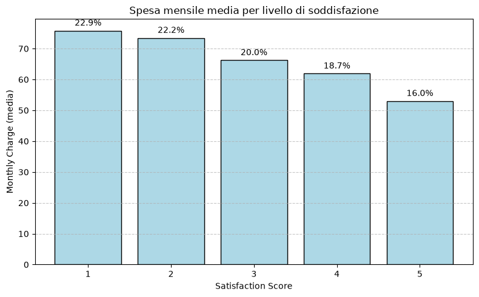

```python
monthly_charge_by_satisfaction = merged_df.groupby('Satisfaction Score')['Monthly Charge'].mean()

total = monthly_charge_by_satisfaction.sum()
percentages = (monthly_charge_by_satisfaction / total) * 100

plt.figure(figsize=(8,5))
bars = plt.bar(
    monthly_charge_by_satisfaction.index,
    monthly_charge_by_satisfaction.values,
    color='lightblue',
    edgecolor='black'
)

for bar, pct in zip(bars, percentages):
    height = bar.get_height()
    plt.text(
        bar.get_x() + bar.get_width()/2,
        height + 1,
        f'{pct:.1f}%',
        ha='center',
        va='bottom',
        fontsize=10
    )

plt.title('Spesa mensile media per livello di soddisfazione')
plt.xlabel('Satisfaction Score')
plt.ylabel('Monthly Charge (media)')
plt.grid(axis='y', linestyle='--', alpha=0.7)
plt.xticks(rotation=0)
plt.tight_layout()
plt.show()
```

Eliminiamo dunque, tutti gli attributi esclusi dall'analisi:

```python
columns_to_drop = [
    'Gender',
    'Multiple Lines',
    'Streaming Music',
    'Avg Monthly Long Distance Charges',
    'Total Refunds',
    'Total Extra Data Charges',
    'Satisfaction Score'
]

merged_df = merged_df.drop(columns=columns_to_drop)
```

Dunque, il dataset pulito si presenta come segue

```python
print(merged_df.info())
print("Dataset Shape:", merged_df.shape)
duplicate_values = merged_df.duplicated().sum()
print("Duplicate Values:", duplicate_values)
```

```
<class 'pandas.DataFrame'>
RangeIndex: 7043 entries, 0 to 7042
Data columns (total 25 columns):
 #   Column                   Non-Null Count  Dtype
---  ------                   --------------  -----
 0   Customer ID              7043 non-null   str
 1   Partner                  7043 non-null   str
 2   Tenure                   7043 non-null   int64
 3   Phone Service            7043 non-null   str
 4   Internet Service         7043 non-null   str
 5   Online Security          7043 non-null   str
 6   Online Backup            7043 non-null   str
 7   Streaming TV             7043 non-null   str
 8   Streaming Movies         7043 non-null   str
 9   Contract                 7043 non-null   str
```

[output cut: 20 more lines]

Inoltre, elimineremo l'attributo Churn dal dataset, in favore di Churn Values. Questo ci è stato utile per rappresentare le lables nei grafici durante l'esplorazione dei dati, ma nel seguito preferiamo usare un attributo binario.

```python
merged_df = merged_df.drop(columns=['Churn'])
counts = merged_df['Churn Value'].value_counts()
print(counts)
pcts = merged_df['Churn Value'].value_counts(normalize=True) * 100
print(pcts)
original_df = merged_df.copy()
```

```
Churn Value
0    5174
1    1869
Name: count, dtype: int64
Churn Value
0    73.463013
1    26.536987
Name: proportion, dtype: float64
```

## Analisi della correlazione tra i dati

Prima di procedere oltre, verifichiamo la presenza di correlazione nei dati.

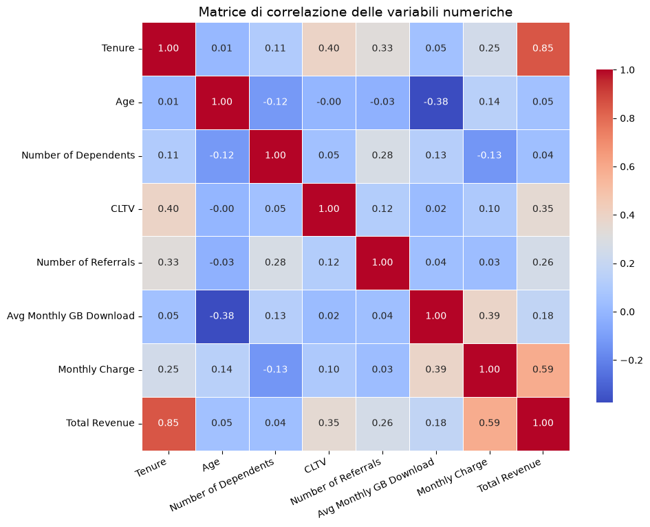

```python
corr_original_df = original_df
corr_original_df = corr_original_df.drop(columns=['Customer ID', 'Churn Value'])

correlation_matrix = corr_original_df.corr(numeric_only=True)
plt.figure(figsize=(10, 8))

sns.heatmap(
    correlation_matrix,
    annot=True,
    fmt=".2f",
    cmap='coolwarm',
    linewidths=0.5,
    square=True,
    cbar_kws={"shrink": 0.75}
)

plt.title("Matrice di correlazione delle variabili numeriche", fontsize=14)
plt.xticks(rotation=25, ha='right')
plt.tight_layout()
plt.show()
```

Emerge alta correlazione tra gli attributi Tenure e Total Revenue. Decidiamo di rimuovere Total Revenue, in quanto useremo Monthly Charge per tenere conto dell'importo addebbitato al cliente.

```python
original_df = original_df.drop(columns=['Total Revenue'])
```

Tuttavia, così facendo, riusciamo a catturare solo variabili numeriche, ma il dataset comprende motli più attributi non numerici, che potrebbero essere correlati.

```python
numerical_cols = original_df.select_dtypes(include=np.number).columns
non_numerical_cols = original_df.select_dtypes(exclude=np.number).columns

print(f"Numero di colonne numeriche: {len(numerical_cols)}")
print(numerical_cols.tolist())
print('\n')
print(f"Numero di colonne non numeriche: {len(non_numerical_cols)}")
print(non_numerical_cols.tolist())
```

```
Numero di colonne numeriche: 8
['Tenure', 'Age', 'Number of Dependents', 'Churn Value', 'CLTV', 'Number of Referrals', 'Avg Monthly GB Download', 'Monthly Charge']


Numero di colonne non numeriche: 15
['Customer ID', 'Partner', 'Phone Service', 'Internet Service', 'Online Security', 'Online Backup', 'Streaming TV', 'Streaming Movies', 'Contract', 'Paperless Billing', 'Payment Method', 'Offer', 'Device Protection Plan', 'Premium Tech Support', 'Unlimited Data']
```

Pertato, realizziamo un mapping tra i valoiri degli attributi ed i numeri naturali, assicurandoci di riscalare gli attributi continui. Usiamo infatti, la standardizzazione Z-score, che sottrae il campione per la media e poi divide per la varianza, rivelandosi robusta agli outliers. Nel nostro caso sono rappresentati dagli attributi che hanno istogrammi contenenti barre con basse percentuali di clienti (>1%).

```python
encoded_df = original_df

encoded_df['Customer ID'] = [i for i in range(len(encoded_df))]

continuous_columns = ['Monthly Charge']

binary_mappings = {
    'Partner': {'No': 0, 'Yes': 1},
    'Phone Service': {'No': 0, 'Yes': 1},
    'Paperless Billing': {'No': 0, 'Yes': 1},
    'Device Protection Plan': {'No': 0, 'Yes': 1},
    'Premium Tech Support': {'No': 0, 'Yes': 1},
    'Unlimited Data': {'No': 0, 'Yes': 1}
}

multi_mappings = {
    'Internet Service': {'No': 0, 'DSL': 1, 'Fiber optic': 2},
    'Online Security': {'No': 0, 'Yes': 1, 'No internet service': 2},
    'Online Backup': {'No': 0, 'Yes': 1, 'No internet service': 2},
    'Streaming TV': {'No': 0, 'Yes': 1, 'No internet service': 2},
    'Streaming Movies': {'No': 0, 'Yes': 1, 'No internet service': 2},
    'Contract': {'Month-to-month': 0, 'One year': 1, 'Two year': 2},
    'Payment Method': {
        'Bank transfer (automatic)': 0,
        'Credit card (automatic)': 1,
        'Electronic check': 2,
        'Mailed check': 3
    },
    'Offer': {
        'Offer A': 0, 'Offer B': 1, 'Offer C': 2, 'Offer D': 3,
        'Offer E': 4, 'No': 5
    }
}

scaler = StandardScaler()
encoded_df[continuous_columns] = scaler.fit_transform(encoded_df[continuous_columns])

for col, mapping in binary_mappings.items():
    encoded_df[col] = encoded_df[col].map(mapping)

for col, mapping in multi_mappings.items():
    encoded_df[col] = encoded_df[col].map(mapping)

print(encoded_df.shape)
print(merged_df.info())
encoded_df.head()
```

```
(7043, 23)
<class 'pandas.DataFrame'>
RangeIndex: 7043 entries, 0 to 7042
Data columns (total 24 columns):
 #   Column                   Non-Null Count  Dtype
---  ------                   --------------  -----
 0   Customer ID              7043 non-null   str
 1   Partner                  7043 non-null   str
 2   Tenure                   7043 non-null   int64
 3   Phone Service            7043 non-null   str
 4   Internet Service         7043 non-null   str
 5   Online Security          7043 non-null   str
 6   Online Backup            7043 non-null   str
 7   Streaming TV             7043 non-null   str
 8   Streaming Movies         7043 non-null   str
```

[output cut: 18 more lines]

|  | Customer ID | Partner | Tenure | Phone Service | Internet Service | Online Security | Online Backup | Streaming TV | Streaming Movies | Contract | ... | Number of Dependents | Churn Value | CLTV | Number of Referrals | Offer | Avg Monthly GB Download | Device Protection Plan | Premium Tech Support | Unlimited Data | Monthly Charge |
| --- | --- | --- | --- | --- | --- | --- | --- | --- | --- | --- | --- | --- | --- | --- | --- | --- | --- | --- | --- | --- | --- |
| 0 | 0 | 1 | 9 | 1 | 1 | 0 | 1 | 1 | 0 | 1 | ... | 0 | 0 | 2205 | 2 | 5 | 16 | 0 | 1 | 1 | 0.027862 |
| 1 | 1 | 0 | 9 | 1 | 1 | 0 | 0 | 0 | 1 | 0 | ... | 0 | 0 | 5414 | 0 | 5 | 10 | 0 | 0 | 0 | -0.161583 |
| 2 | 2 | 0 | 4 | 1 | 2 | 0 | 0 | 0 | 0 | 0 | ... | 0 | 1 | 4479 | 0 | 4 | 30 | 1 | 0 | 1 | 0.303720 |
| 3 | 3 | 1 | 13 | 1 | 2 | 0 | 1 | 1 | 1 | 0 | ... | 0 | 1 | 3714 | 1 | 3 | 4 | 1 | 0 | 1 | 1.104706 |
| 4 | 4 | 1 | 3 | 1 | 2 | 0 | 0 | 1 | 0 | 0 | ... | 0 | 1 | 3464 | 3 | 5 | 11 | 0 | 1 | 1 | 0.636080 |

5 rows × 23 columns

Vediamone dunque, la matrice di correlazione

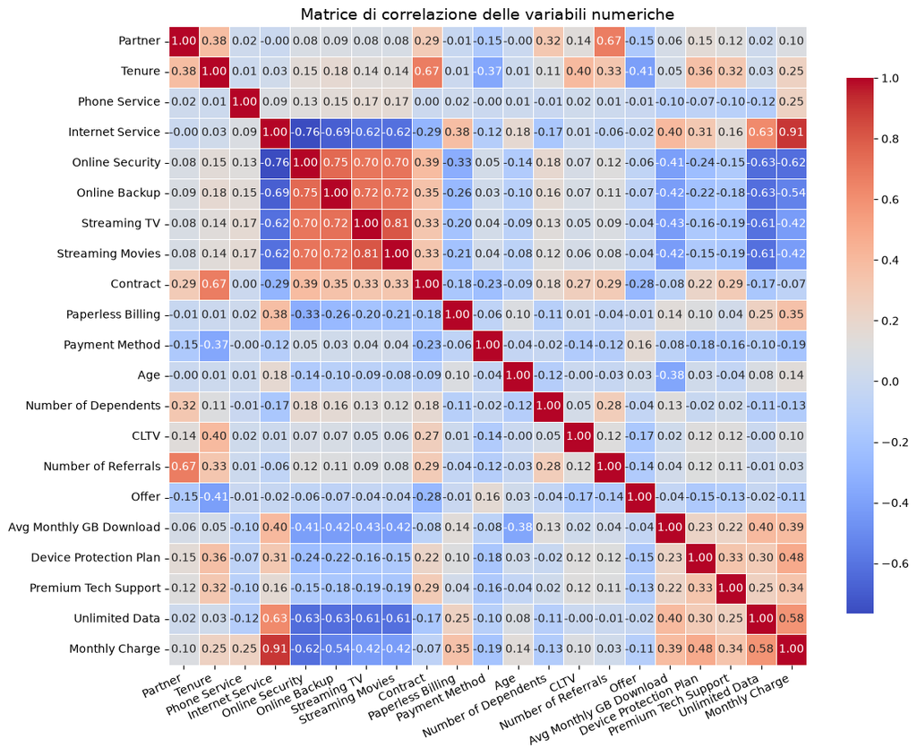

```python
corr_encoded_df = encoded_df.copy()
corr_encoded_df = corr_encoded_df.drop(columns=['Customer ID', 'Churn Value'])

correlation_matrix = corr_encoded_df.corr(numeric_only=True)
plt.figure(figsize=(12, 10))

sns.heatmap(
    correlation_matrix,
    annot=True,
    fmt=".2f",
    cmap='coolwarm',
    linewidths=0.5,
    square=True,
    cbar_kws={"shrink": 0.75}
)

plt.title("Matrice di correlazione delle variabili numeriche", fontsize=14)
plt.xticks(rotation=25, ha='right')
plt.tight_layout()
plt.show()
```

In questo caso risultano presenti diversi attributi altamente correlati tra loro. Diversi algoritmi di classificazione non risentono della correlazione, quindi ci preoccuperemo di rimuovere dal dataset gli attributi correlati al momento opportuno.

Osserviamo quali colonne spiegano maggiormente la varianza del dataset eseguendo la Principal Compoment Analysis.

```
Numero totale di componenti: 21

Componenti necessarie per soglie di varianza:
-------------------------------------------
80% varianza: 10 componenti (cumulativa: 82.74%)
90% varianza: 13 componenti (cumulativa: 90.44%)
95% varianza: 16 componenti (cumulativa: 95.59%)
99% varianza: 20 componenti (cumulativa: 99.89%)

Top 16 variabili più importanti per PC1:
-------------------------------------
Online Security            0.369292
Internet Service           0.368130
Online Backup              0.357399
Streaming Movies           0.343107
Streaming TV               0.343015
Unlimited Data             0.327364
Monthly Charge             0.319721
Avg Monthly GB Download    0.225172
Paperless Billing          0.167258
Contract                   0.153382
Device Protection Plan     0.148997
Premium Tech Support       0.114774
Number of Dependents       0.085767
Age                        0.051703
Number of Referrals        0.047870
Payment Method             0.044545
dtype: float64
```

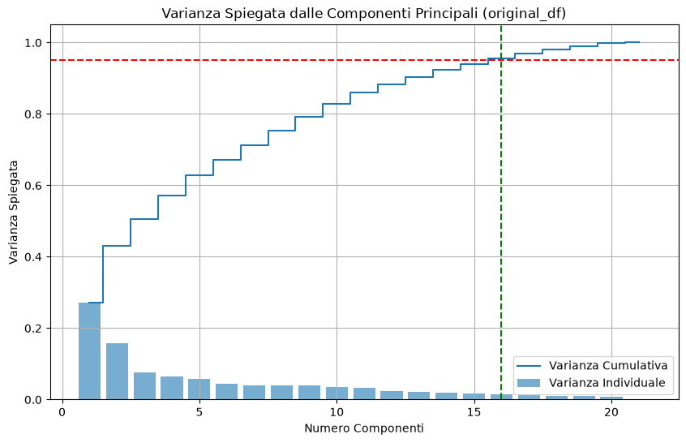

```python
pca_original_df = original_df.copy()
pca_original_df = pca_original_df.drop(columns=['Customer ID', 'Churn Value'])

X = pca_original_df.select_dtypes(include=['int64', 'float64'])

scaler = StandardScaler()
X_scaled = scaler.fit_transform(X)

pca = PCA()
X_pca = pca.fit_transform(X_scaled)

variance_ratio = pca.explained_variance_ratio_
cumulative_variance = np.cumsum(variance_ratio)

thresholds = [0.80, 0.90, 0.95, 0.99]
print(f"Numero totale di componenti: {pca.n_components_}")
print("\nComponenti necessarie per soglie di varianza:")
print("-------------------------------------------")
for threshold in thresholds:
    n_components = np.argmax(cumulative_variance >= threshold) + 1
    print(f"{threshold*100:.0f}% varianza: {n_components} componenti (cumulativa: {cumulative_variance[n_components-1]*100:.2f}%)")

print("\nTop 16 variabili più importanti per PC1:")
print("-------------------------------------")
loadings_pc1 = pd.Series(pca.components_[0], index=X.columns)
loadings_pc1_sorted = loadings_pc1.abs().sort_values(ascending=False)
print(loadings_pc1_sorted.head(16))

plt.figure(figsize=(10, 6))
plt.bar(range(1, len(variance_ratio)+1), variance_ratio, alpha=0.6, label='Varianza Individuale')
plt.step(range(1, len(cumulative_variance)+1), cumulative_variance, where='mid', label='Varianza Cumulativa')
plt.title("Varianza Spiegata dalle Componenti Principali (original_df)")
plt.xlabel("Numero Componenti")
plt.ylabel("Varianza Spiegata")
plt.legend()
plt.grid(True)
plt.axhline(y=0.95, color='r', linestyle='--', label='95% Varianza')
plt.axvline(x=np.argmax(cumulative_variance >= 0.95) + 1, color='g', linestyle='--')
plt.show()
```

```python
selected_columns = [
    "Customer ID",
    'Online Security',
    'Internet Service',
    'Online Backup',
    'Streaming Movies',
    'Streaming TV',
    'Unlimited Data',
    'Monthly Charge',
    'Avg Monthly GB Download',
    'Paperless Billing',
    'Contract',
    'Device Protection Plan',
    'Premium Tech Support',
    'Number of Dependents',
    'Age',
    'Number of Referrals',
    'Payment Method',
    "Churn Value"
]

cleaned_df = original_df[selected_columns].copy()
```

# **Algoritmi di Clustering**

Questa sezione è redatta al fine di scoprire pattern ricorrenti nei dati e individuare eventuali gruppi di clienti con caratteristiche simili. Nonostante sia stata effettuata un'analisi tramite PCA, procediamo con ulteriori analisi per valutare le differenze tra gli algoritmi di clustering, utilizzando dataset con diverse combinazioni di variabili e correlazioni.

```python
from sklearn.preprocessing import StandardScaler, OneHotEncoder
from sklearn.compose import ColumnTransformer
from sklearn.cluster import KMeans
from sklearn.decomposition import PCA
from sklearn.metrics import silhouette_score
from sklearn.neighbors import NearestNeighbors
import numpy as np
import pandas as pd
from sklearn.cluster import DBSCAN
```

## Analisi del dataset originario

Svolgiamo prima clustering sul dataset originario.

Prima di procedere, selezioniamo gli attributi che meglio si prestano al clustering (attributi numerici).

```python
columns_to_use = [col for col in original_df.columns if col != 'Customer ID']
print(columns_to_use)

numeric_cols = original_df[columns_to_use].select_dtypes(include=['int64', 'float64']).columns

n_unique_threshold = 10
continuous_cols = []
categorical_numeric_cols = []

for col in numeric_cols:
    n_unique = original_df[col].nunique()
    if n_unique > n_unique_threshold:
        continuous_cols.append(col)
    else:
        categorical_numeric_cols.append(col)

columns_for_clustering = [col for col in columns_to_use if col != 'Churn_Value']
clustering_original_df = original_df[columns_for_clustering]

categorical_cols = clustering_original_df.select_dtypes(include=['object']).columns.tolist() + categorical_numeric_cols

preprocessor = ColumnTransformer(
    transformers=[
        ('num', StandardScaler(), continuous_cols),
        ('cat', OneHotEncoder(handle_unknown='ignore'), categorical_cols)
    ]
)

X_prepared = preprocessor.fit_transform(clustering_original_df)
```

```
['Partner', 'Tenure', 'Phone Service', 'Internet Service', 'Online Security', 'Online Backup', 'Streaming TV', 'Streaming Movies', 'Contract', 'Paperless Billing', 'Payment Method', 'Age', 'Number of Dependents', 'Churn Value', 'CLTV', 'Number of Referrals', 'Offer', 'Avg Monthly GB Download', 'Devi…
```

A questo punto, calcoliamo il silhouette score e confrontiamolo con il metodo del gomito.

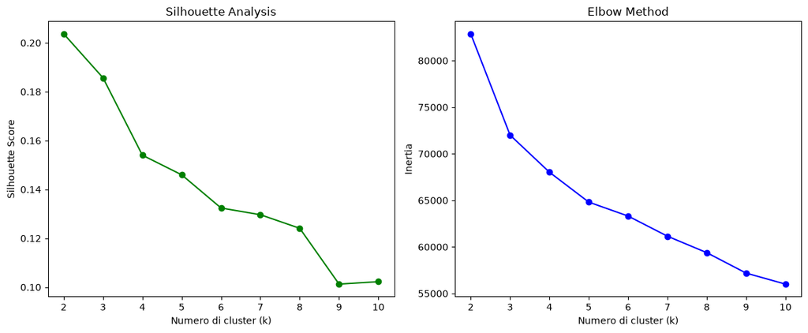

```python
silhouette_scores = []
inertias = []
K_range = range(2, 11)

for k in K_range:
    kmeans = KMeans(n_clusters=k, random_state=42)
    cluster_labels = kmeans.fit_predict(X_prepared)
    score = silhouette_score(X_prepared, cluster_labels)
    silhouette_scores.append(score)
    inertias.append(kmeans.inertia_)

plt.figure(figsize=(12, 5))

plt.subplot(1, 2, 1)
plt.plot(K_range, silhouette_scores, 'go-')
plt.xlabel('Numero di cluster (k)')
plt.ylabel('Silhouette Score')
plt.title('Silhouette Analysis')

plt.subplot(1, 2, 2)
plt.plot(K_range, inertias, 'bo-')
plt.xlabel('Numero di cluster (k)')
plt.ylabel('Inertia')
plt.title('Elbow Method')

plt.tight_layout()
plt.show()
```

Il silhouette score è un indice che serve per calcolare il numero k. È definito come un rapporto tra la differenza tra la distanza di un punto da ciascun punto dello stesso cluster (coerenza) e la distanza media più bassa tra un punto e i punti di cluster diversi (separabilità) diviso il massimo di uno di questi due valori: Per valori di silhouette dai 0,7 a 1 il cluster (valore k) è ottimo per valori molto inferiori a 0,5 il cluster non è ottimo.

Decidiamo di dividere i campioni in 2 clusters usando l'algoritmo k-Means++.

```python
n_clusters = 2
kmeans = KMeans(n_clusters=n_clusters, random_state=42)
clusters = kmeans.fit_predict(X_prepared)
```

Osserviamo la distribuzione dei clienti che fanno (o no) Churn nei diversi cluster.

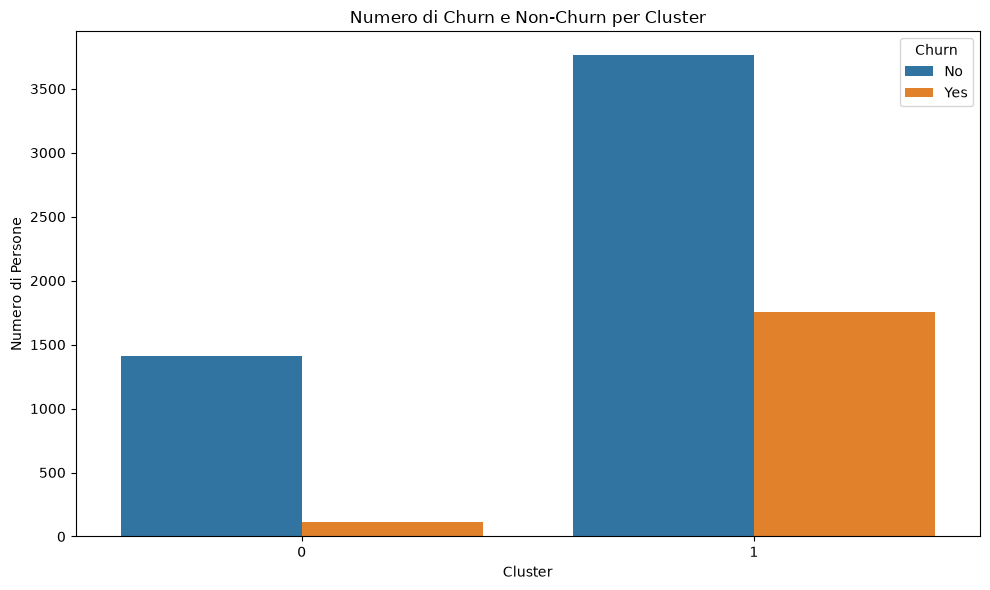

```python
clustering_original_df['Cluster'] = clusters

clustering_original_df['Churn Label'] = clustering_original_df['Churn Value'].map({0: 'No', 1: 'Yes'})

plt.figure(figsize=(10, 6))
ax = sns.countplot(
    x='Cluster',
    hue='Churn Label',
    data=clustering_original_df,
    palette='tab10'
)
plt.title('Numero di Churn e Non-Churn per Cluster')
plt.xlabel('Cluster')
plt.ylabel('Numero di Persone')
plt.legend(title='Churn')
plt.tight_layout()
plt.show()
```

Osserviamo che nel cluster 0 la percentuale di clienti che fa Churn è molto bassa, contrariamente a quanto avviene nel cluster 1.

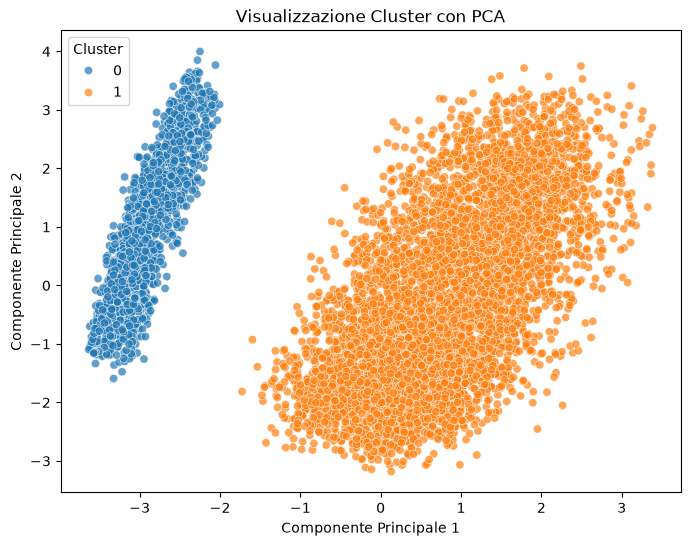

```python
pca = PCA(n_components=2)
X_pca = pca.fit_transform(X_prepared.toarray() if hasattr(X_prepared, "toarray") else X_prepared)

plt.figure(figsize=(8,6))
sns.scatterplot(x=X_pca[:,0], y=X_pca[:,1], hue=clustering_original_df['Cluster'], palette='tab10', alpha=0.7)
plt.title('Visualizzazione Cluster con PCA')
plt.xlabel('Componente Principale 1')
plt.ylabel('Componente Principale 2')
plt.legend(title='Cluster')
plt.show()
```

```
Top 3 variabili numeriche per cluster (per differenza dalla media globale):
Cluster 0: ['CLTV', 'Avg Monthly GB Download', 'Age']
Cluster 1: ['CLTV', 'Avg Monthly GB Download', 'Age']

Top 3 variabili categoriche per cluster (per frequenza della moda):
Cluster 0: ['Phone Service', 'Internet Service', 'Online Security']
Cluster 1: ['Phone Service', 'Unlimited Data', 'Number of Dependents']
```

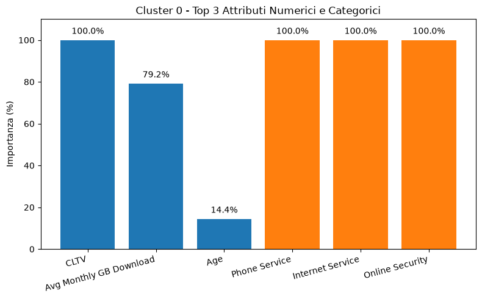

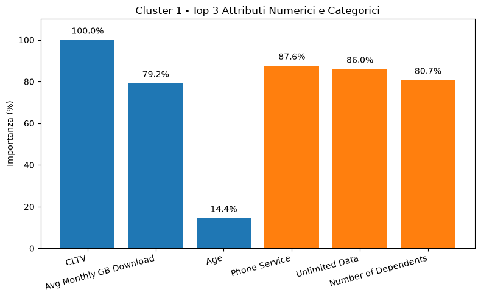

```python
numeric_summary = clustering_original_df.groupby('Cluster')[continuous_cols].mean()

global_means = clustering_original_df[continuous_cols].mean()

numeric_diff = numeric_summary.subtract(global_means).abs()

top3_numeric_per_cluster = {}
for cluster in numeric_diff.index:
    top3 = numeric_diff.loc[cluster].sort_values(ascending=False).head(3).index.tolist()
    top3_numeric_per_cluster[cluster] = top3

print("Top 3 variabili numeriche per cluster (per differenza dalla media globale):")
for cluster, vars_ in top3_numeric_per_cluster.items():
    print(f"Cluster {cluster}: {vars_}")

def mode_freq_per_cluster(df, group_col, cols):
    freq_dict = {}
    for col in cols:
        freq_cluster = {}
        for cluster, group in df.groupby(group_col):
            mode_val = group[col].mode()
            if mode_val.empty:
                freq = 0
            else:
                mode_val = mode_val.iloc[0]
                freq = (group[col] == mode_val).mean()
            freq_cluster[cluster] = freq
        freq_dict[col] = freq_cluster
    return pd.DataFrame(freq_dict).T

categorical_cols = [col for col in categorical_cols if col != 'Churn Value']
categorical_mode_freq = mode_freq_per_cluster(clustering_original_df, 'Cluster', categorical_cols)

top3_categorical_per_cluster = {}
for cluster in categorical_mode_freq.columns:
    top3 = categorical_mode_freq[cluster].sort_values(ascending=False).head(3).index.tolist()
    top3_categorical_per_cluster[cluster] = top3

print("\nTop 3 variabili categoriche per cluster (per frequenza della moda):")
for cluster, vars_ in top3_categorical_per_cluster.items():
    print(f"Cluster {cluster}: {vars_}")
print("\n")

def plot_top_attributes_bars(top_numeric, numeric_diff, top_categorical, categorical_mode_freq):
    clusters = sorted(top_numeric.keys())

    for cluster in clusters:
        numeric_attrs = top_numeric[cluster]
        numeric_vals = numeric_diff.loc[cluster, numeric_attrs].values

        numeric_perc = 100 * numeric_vals / numeric_vals.max() if numeric_vals.max() > 0 else numeric_vals

        categorical_attrs = top_categorical[cluster]
        categorical_vals = categorical_mode_freq.loc[categorical_attrs, cluster].values

        categorical_perc = 100 * categorical_vals

        attrs = numeric_attrs + categorical_attrs
        vals = np.concatenate([numeric_perc, categorical_perc])

        colors = ['tab:blue'] * len(numeric_attrs) + ['tab:orange'] * len(categorical_attrs)

        plt.figure(figsize=(8, 5))
        bars = plt.bar(attrs, vals, color=colors)

        for bar, val in zip(bars, vals):
            plt.text(bar.get_x() + bar.get_width()/2, bar.get_height() + 2, f'{val:.1f}%', ha='center', va='bottom')

        plt.ylim(0, 110)
        plt.title(f'Cluster {cluster} - Top 3 Attributi Numerici e Categorici')
        plt.ylabel('Importanza (%)')
        plt.xticks(rotation=15, ha='right')
        plt.tight_layout()
        plt.show()

plot_top_attributes_bars(top3_numeric_per_cluster, numeric_diff, top3_categorical_per_cluster, categorical_mode_freq)
```

```python
df = clustering_original_df.copy()

df = df.drop(columns=['Customer ID', 'Cluster', 'Churn Value', 'Churn Label'], errors='ignore')

X = df.values

eps_list = [0.1, 10, 100]
min_samples_list = [5, 10, 50, 100]

best_score = -1
best_params = {}

for eps in eps_list:
    for ms in min_samples_list:
        db = DBSCAN(eps=eps, min_samples=ms)
        labels = db.fit_predict(X)
        n_clusters = len(set(labels)) - (1 if -1 in labels else 0)
        if n_clusters < 2:
            continue
        score = silhouette_score(X, labels)
        if score > best_score:
            best_score = score
            best_params = {'eps': eps, 'min_samples': ms}

if best_params is None:
    print("Non è stata trovata alcuna combinazione con ≥2 cluster.")
    print("    • Prova a guardare il K-distance plot sopra per individuare un eps ragionevole.")
    print("    • Puoi ridurre min_samples o espandere ancora eps.")
else:
    print(f"Migliori parametri: eps = {best_params['eps']:.2f}, "
          f"min_samples = {best_params['min_samples']} → silhouette = {best_score:.4f}")
```

```
Migliori parametri: eps = 10.00, min_samples = 5 → silhouette = -0.6229
```

L'analisi di questi parametri suggerisce che l'algoritmo DBSCAN sia non efficiente per la clusterizzazione, il parametro eps e' molto alto per gli standard questo significa che per trovare un cluster buono il raggio deve essere pari a 10.00 mentre la silhoutte suggerisce che molti punti siano piu' vicini a cluster sbagliati, il resoconto e' che i dati risultino molto sparsi.

Si effettua clustering eliminando le colonne che risultano correlate questo per avere vantaggi nell'esecuzione dell'algoritmo K-Means++ in quanto risulta ridotta la dimensionalità del dataset e inoltre si vuole evitare ridondanza nell'output dell'algoritmo. Si prepara il dataset per il clustering

```python
columns_to_use = [col for col in cleaned_df.columns if col != 'Customer ID']
print(columns_to_use)

numeric_cols = cleaned_df[columns_to_use].select_dtypes(include=['int64', 'float64']).columns

n_unique_threshold = 10
continuous_cols = []
categorical_numeric_cols = []

for col in numeric_cols:
    n_unique = cleaned_df[col].nunique()
    if n_unique > n_unique_threshold:
        continuous_cols.append(col)
    else:
        categorical_numeric_cols.append(col)

columns_for_clustering = [col for col in columns_to_use if col != 'Churn_Value']
clustering_cleaned_df = cleaned_df[columns_for_clustering]

categorical_cols = clustering_cleaned_df.select_dtypes(include=['object']).columns.tolist() + categorical_numeric_cols

preprocessor = ColumnTransformer(
    transformers=[
        ('num', StandardScaler(), continuous_cols),
        ('cat', OneHotEncoder(handle_unknown='ignore'), categorical_cols)
    ]
)

X_prepared = preprocessor.fit_transform(clustering_cleaned_df)
```

```
['Online Security', 'Internet Service', 'Online Backup', 'Streaming Movies', 'Streaming TV', 'Unlimited Data', 'Monthly Charge', 'Avg Monthly GB Download', 'Paperless Billing', 'Contract', 'Device Protection Plan', 'Premium Tech Support', 'Number of Dependents', 'Age', 'Number of Referrals', 'Paymen…
```

Controlliamo il silhouette score e confrontiamolo con il metodo del gomito

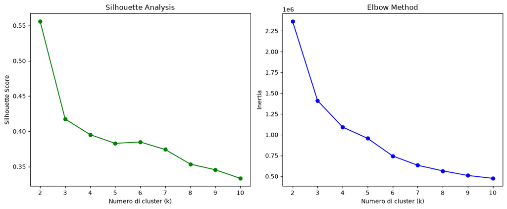

```python
silhouette_scores = []
inertias = []
K_range = range(2, 11)

for k in K_range:
    kmeans = KMeans(n_clusters=k, random_state=42)
    cluster_labels = kmeans.fit_predict(clustering_cleaned_df)
    score = silhouette_score(clustering_cleaned_df, cluster_labels)
    silhouette_scores.append(score)
    inertias.append(kmeans.inertia_)

plt.figure(figsize=(12, 5))

plt.subplot(1, 2, 1)
plt.plot(K_range, silhouette_scores, 'go-')
plt.xlabel('Numero di cluster (k)')
plt.ylabel('Silhouette Score')
plt.title('Silhouette Analysis')

plt.subplot(1, 2, 2)
plt.plot(K_range, inertias, 'bo-')
plt.xlabel('Numero di cluster (k)')
plt.ylabel('Inertia')
plt.title('Elbow Method')

plt.tight_layout()
plt.show()
```

```
Churn Value
No     5174
Yes    1869
Name: count, dtype: int64
```

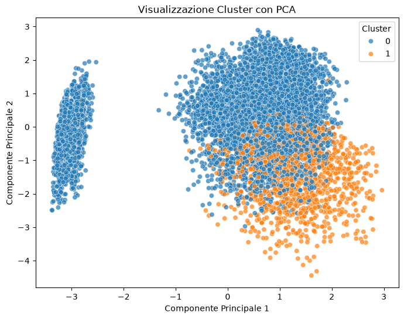

```python
n_clusters = 2
kmeans = KMeans(n_clusters=n_clusters, random_state=42)
clusters = kmeans.fit_predict(clustering_cleaned_df)

clustering_cleaned_df['Cluster'] = clusters
clustering_cleaned_df['Churn Value'] = cleaned_df['Churn Value'].map({0: 'No', 1: 'Yes'})
counts = clustering_cleaned_df['Churn Value'].value_counts()
print(counts)

pca = PCA(n_components=2)
X_pca = pca.fit_transform(X_prepared.toarray() if hasattr(X_prepared, "toarray") else X_prepared)

plt.figure(figsize=(8,6))
sns.scatterplot(x=X_pca[:,0], y=X_pca[:,1], hue=clustering_cleaned_df['Cluster'], palette='tab10', alpha=0.7)
plt.title('Visualizzazione Cluster con PCA')
plt.xlabel('Componente Principale 1')
plt.ylabel('Componente Principale 2')
plt.legend(title='Cluster')
plt.show()
```

Come possiamo vedere la rimozione di attributi correlati porta alla creazione di due cluster ben diversi dai precedenti, sappiamo a livello teorico che la correlazione può in qualche modo influenzare negativamente la clusterizzazione portando a delle misure della distanza distorte.

# Applicazione degli algoritmi di Classificazione

Importiamo le librerie necessarie per la creazione dei nostri modelli di classificazione

```python
import numpy as np
import pandas as pd
import matplotlib.pyplot as plt
import seaborn as sns
import graphviz
from rich.console import Console
from rich.table import Table
from sklearn.base import clone
from sklearn.ensemble import AdaBoostClassifier, RandomForestClassifier
from sklearn.metrics import accuracy_score, precision_score, recall_score, f1_score, classification_report, confusion_matrix
from sklearn.model_selection import ParameterGrid, train_test_split
from sklearn.naive_bayes import GaussianNB
from sklearn.neural_network import MLPClassifier
from sklearn.pipeline import make_pipeline
from sklearn.preprocessing import StandardScaler
from sklearn.svm import SVC, LinearSVC
from sklearn.tree import DecisionTreeClassifier, export_graphviz
from xgboost import XGBClassifier
```

Come prima operazione si eliminano le colonne fortemente correlate questo per evitare problemi di classificazione in alcuni algoritmi che si utilizzano successivamente si selezionano i features più rilevanti e il target dopodichè suddividiamo il dataset in training set, test set e validation set prestando attenzione alle variabili categoriche.

```python
columns_to_use = [col for col in original_df.columns if col != 'Customer ID']
columns_present = [col for col in columns_to_use if col in original_df.columns]
missing_cols = [col for col in columns_to_use if col not in original_df.columns]

if missing_cols:
    print("Colonne mancanti e ignorate:", missing_cols)

# 2. Identifica colonne numeriche
numeric_cols = original_df[columns_present].select_dtypes(include=['int64', 'float64']).columns

# 3. Calcola matrice di correlazione assoluta
corr_matrix = original_df[numeric_cols].corr().abs()

# 4. Crea maschera triangolare superiore
upper = corr_matrix.where(np.triu(np.ones(corr_matrix.shape), k=1).astype(bool))

# 5. Trova colonne da rimuovere per alta correlazione
to_drop = [column for column in upper.columns if any(upper[column] > 0.8)]
print("Colonne rimosse per alta correlazione:", to_drop)

# 6. Rimuovi colonne fortemente correlate e target
target_column = 'Churn Value'
reduced_columns = [col for col in columns_present if col not in to_drop and col != target_column]

# 7. Crea X e y
X = original_df[reduced_columns]
y = original_df[target_column]

# 8. Suddividi in train/test/validation
X_temp, X_test, y_temp, y_test = train_test_split(
    X, y, test_size=0.2, random_state=42, stratify=y)
X_train_raw, X_val_raw, y_train, y_val = train_test_split(
    X_temp, y_temp, test_size=0.25, random_state=42, stratify=y_temp)

# 9. Unione per encoding
X_all = pd.concat([X_train_raw, X_val_raw, X_test])

# 10. Encoding colonne categoriche
categorical_cols = X_all.select_dtypes(include=['object', 'category']).columns.tolist()
X_all_encoded = pd.get_dummies(X_all, columns=categorical_cols, drop_first=True)

# 11. Ricostruzione dei dataset
X_train = X_all_encoded.iloc[:len(X_train_raw)]
X_val = X_all_encoded.iloc[len(X_train_raw):len(X_train_raw)+len(X_val_raw)]
X_test = X_all_encoded.iloc[len(X_train_raw)+len(X_val_raw):]

# 12. Output informativo
print("\nColonne categoriche trasformate:", categorical_cols)
print("Numero colonne finali dopo encoding:", X_all_encoded.shape[1])
print("\nColonna".ljust(40), "Valore")
print("-" * 50)
for col in X_train.columns:
    print(col.ljust(40), X_train[col].iloc[0])

original_results=[]
```

```
Colonne rimosse per alta correlazione: ['Streaming Movies', 'Monthly Charge']

Colonne categoriche trasformate: []
Numero colonne finali dopo encoding: 19

Colonna                                 Valore
--------------------------------------------------
Partner                                  0
Tenure                                   12
Phone Service                            1
Internet Service                         2
Online Security                          0
Online Backup                            0
Streaming TV                             1
Contract                                 0
Paperless Billing                        0
Payment Method                           2
Age                                      38
Number of Dependents                     0
CLTV                                     5674
Number of Referrals                      0
Offer                                    3
Avg Monthly GB Download                  8
Device Protection Plan                   0
Premium Tech Support                     0
Unlimited Data                           1
```

### Protocollo di valutazione

I tre insiemi hanno ruoli distinti:

- **train set (60%)**: addestramento dei modelli;
- **validation set (20%)**: *solo* scelta degli iperparametri. Per ogni modello si prova ogni combinazione di una griglia, si addestra su train e si sceglie quella con la migliore accuracy sul validation;
- **test set (20%)**: usato *una sola volta* per ogni modello, dopo la scelta degli iperparametri, per stimare la performance su dati mai visti. Non guida nessuna decisione.

Il modello scelto resta addestrato sul solo train set, così tutti gli algoritmi vedono gli stessi dati e i risultati sul test sono confrontabili.

```python
console = Console()
CLASS_NAMES = ['No Churn', 'Yes Churn']
SELECTION_METRIC = accuracy_score  # metrica usata sul validation per scegliere gli iperparametri


def metrics(y_true, y_pred):
    return {
        'Accuracy': accuracy_score(y_true, y_pred),
        'Precision': precision_score(y_true, y_pred, zero_division=0),
        'Recall': recall_score(y_true, y_pred, zero_division=0),
        'F1-score': f1_score(y_true, y_pred, zero_division=0),
    }


def show_report(title, y_true, y_pred, cmap='Blues'):
    report = classification_report(y_true, y_pred, target_names=CLASS_NAMES, output_dict=True, zero_division=0)
    table = Table(title=f"{title}\nAccuracy: {report['accuracy']:.4f}", title_style="bold green")
    for col in ("Class", "Precision", "Recall", "F1-Score", "Support"):
        table.add_column(col, justify="left" if col == "Class" else "center")
    for label in CLASS_NAMES + ['macro avg', 'weighted avg']:
        r = report[label]
        table.add_row(label, f"{r['precision']:.4f}", f"{r['recall']:.4f}", f"{r['f1-score']:.4f}", str(int(r['support'])))
    console.print(table)

    plt.figure(figsize=(5, 4))
    sns.heatmap(confusion_matrix(y_true, y_pred), annot=True, fmt='d', cmap=cmap, cbar=False,
                xticklabels=CLASS_NAMES, yticklabels=CLASS_NAMES)
    plt.xlabel('Predicted')
    plt.ylabel('Actual')
    plt.title(f'Confusion Matrix - {title}')
    plt.show()


def tune_on_validation(estimator, grid):
    """Sceglie gli iperparametri sul validation set: fit su train, punteggio su validation."""
    rows, best = [], None
    for params in ParameterGrid(grid):
        model = clone(estimator).set_params(**params).fit(X_train, y_train)
        score = SELECTION_METRIC(y_val, model.predict(X_val))
        rows.append({**params, 'validation': score})
        if best is None or score > best[0]:
            best = (score, params, model)
    table = pd.DataFrame(rows).sort_values('validation', ascending=False).reset_index(drop=True)
    print(f"Migliori iperparametri (validation): {best[1]}  ->  {best[0]:.4f}")
    return best[2], best[1], best[0], table


def evaluate_on_test(name, model, params, cmap='Blues'):
    """Test set usato una sola volta, sul modello gia' scelto in validazione."""
    y_val_pred, y_test_pred = model.predict(X_val), model.predict(X_test)
    show_report(f'Test Report - {name}', y_test, y_test_pred, cmap)
    row = {'Algorithm': name, 'Best params': str(params)}
    row.update({f'{k} (Validation)': v for k, v in metrics(y_val, y_val_pred).items()})
    row.update({f'{k} (Test)': v for k, v in metrics(y_test, y_test_pred).items()})
    original_results.append(row)
```

## Decision Tree

Come primo algoritmo di classificazione, abbiamo scelto di utilizzare un albero di decisione. Questa scelta è motivata dalla semplicità interpretativa del modello, che consente di comprendere facilmente le regole decisionali alla base della classificazione. Inoltre, gli alberi di decisione gestiscono bene sia variabili numeriche che categoriche, e richiedono una pre-elaborazione minima dei dati. Queste caratteristiche lo rendono una scelta naturale per una prima analisi esplorativa del problema di classificazione.

Un albero senza vincoli va in overfitting: scegliamo sul validation criterio di split, profondità massima e numero minimo di esempi per foglia.

```
Migliori iperparametri (validation): {'criterion': 'gini', 'max_depth': 10, 'min_samples_leaf': 50}  ->  0.8098
```

```
               Test Report - Decision Tree
                     Accuracy: 0.7991
┏━━━━━━━━━━━━━━┳━━━━━━━━━━━┳━━━━━━━━┳━━━━━━━━━━┳━━━━━━━━━┓
┃ Class        ┃ Precision ┃ Recall ┃ F1-Score ┃ Support ┃
┡━━━━━━━━━━━━━━╇━━━━━━━━━━━╇━━━━━━━━╇━━━━━━━━━━╇━━━━━━━━━┩
│ No Churn     │  0.8339   │ 0.9072 │  0.8690  │  1035   │
│ Yes Churn    │  0.6608   │ 0.5000 │  0.5693  │   374   │
│ macro avg    │  0.7474   │ 0.7036 │  0.7191  │  1409   │
│ weighted avg │  0.7880   │ 0.7991 │  0.7895  │  1409   │
└──────────────┴───────────┴────────┴──────────┴─────────┘
```

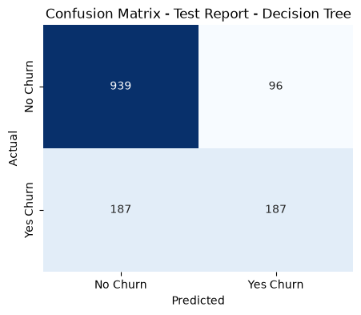

```python
dt, dt_params, dt_val, dt_table = tune_on_validation(
    DecisionTreeClassifier(random_state=42),
    {'criterion': ['gini', 'entropy'], 'max_depth': [3, 5, 7, 10, None], 'min_samples_leaf': [1, 5, 10, 20, 50]},
)
evaluate_on_test('Decision Tree', dt, dt_params)
```

**Decision Tree**: iperparametri scelti sul validation `{'criterion': 'gini', 'max_depth': 10, 'min_samples_leaf': 50}`. Accuracy 81.0% sul validation e 79.9% sul test (-1.1 punti); precision 0.66, recall 0.50, F1 0.57. Il test è più basso del validation di oltre un punto; con circa 1400 esempi per insieme l'errore standard dell'accuracy è di circa un punto, quindi la differenza è compatibile con la variabilità dello split.

Per una migliore leggibilità, esportiamo l'albero in formato pdf.

```python
dot_data = export_graphviz(dt, out_file=None, feature_names=X_train.columns, class_names=CLASS_NAMES,
                           filled=True, rounded=True, special_characters=True)
try:
    graphviz.Source(dot_data).render("decision_tree", cleanup=True)  # richiede il programma Graphviz installato
except graphviz.backend.ExecutableNotFound:
    print("Graphviz non installato: export dell'albero saltato")
```

```
Graphviz non installato: export dell'albero saltato
```

## AdaBoost and XGBoost Classifier

Per cercare di migliorare le prestazioni ottenute con l’albero di decisione, decidiamo di utilizzare una tecnica di Boosting, in particolare useremo AdaBoost e XGBoost, noto per l'efficienza e l'efficacia su molti dataset.

Il Boosting è una tecnica di ensemble che costruisce una sequenza di modelli deboli (come alberi di decisione poco profondi), dove ciascun modello cerca di correggere gli errori del precedente. Questo approccio consente al modello finale di focalizzarsi sulle osservazioni difficili da classificare, migliorando la capacità predittiva complessiva.

```
Migliori iperparametri (validation): {'learning_rate': 1.0, 'n_estimators': 400}  ->  0.8204
```

```
                  Test Report - AdaBoost
                     Accuracy: 0.8105
┏━━━━━━━━━━━━━━┳━━━━━━━━━━━┳━━━━━━━━┳━━━━━━━━━━┳━━━━━━━━━┓
┃ Class        ┃ Precision ┃ Recall ┃ F1-Score ┃ Support ┃
┡━━━━━━━━━━━━━━╇━━━━━━━━━━━╇━━━━━━━━╇━━━━━━━━━━╇━━━━━━━━━┩
│ No Churn     │  0.8629   │ 0.8821 │  0.8724  │  1035   │
│ Yes Churn    │  0.6524   │ 0.6123 │  0.6317  │   374   │
│ macro avg    │  0.7577   │ 0.7472 │  0.7521  │  1409   │
│ weighted avg │  0.8071   │ 0.8105 │  0.8085  │  1409   │
└──────────────┴───────────┴────────┴──────────┴─────────┘
```

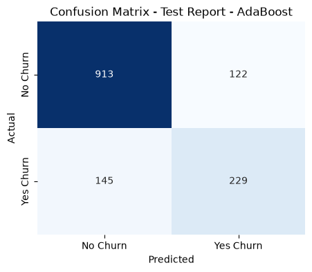

```python
ada, ada_params, ada_val, ada_table = tune_on_validation(
    AdaBoostClassifier(random_state=42),
    {'n_estimators': [50, 100, 200, 400], 'learning_rate': [0.05, 0.1, 0.5, 1.0]},
)
evaluate_on_test('AdaBoost', ada, ada_params)
```

**AdaBoost**: iperparametri scelti sul validation `{'learning_rate': 1.0, 'n_estimators': 400}`. Accuracy 82.0% sul validation e 81.0% sul test (-1.0 punti); precision 0.65, recall 0.61, F1 0.63. Validation e test coincidono entro un punto.

Vediamo se una versione più recente dell'algoritmo di Boosting può migliorare ulteriormente i risultati.

```
Migliori iperparametri (validation): {'learning_rate': 0.03, 'max_depth': 5, 'n_estimators': 200}  ->  0.8268
```

```
                  Test Report - XGBoost
                     Accuracy: 0.8176
┏━━━━━━━━━━━━━━┳━━━━━━━━━━━┳━━━━━━━━┳━━━━━━━━━━┳━━━━━━━━━┓
┃ Class        ┃ Precision ┃ Recall ┃ F1-Score ┃ Support ┃
┡━━━━━━━━━━━━━━╇━━━━━━━━━━━╇━━━━━━━━╇━━━━━━━━━━╇━━━━━━━━━┩
│ No Churn     │  0.8663   │ 0.8889 │  0.8774  │  1035   │
│ Yes Churn    │  0.6686   │ 0.6203 │  0.6436  │   374   │
│ macro avg    │  0.7674   │ 0.7546 │  0.7605  │  1409   │
│ weighted avg │  0.8138   │ 0.8176 │  0.8154  │  1409   │
└──────────────┴───────────┴────────┴──────────┴─────────┘
```

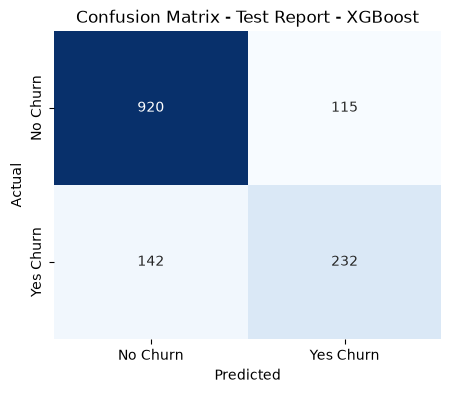

```python
xgb, xgb_params, xgb_val, xgb_table = tune_on_validation(
    XGBClassifier(eval_metric='logloss', random_state=42, n_jobs=-1),
    {'n_estimators': [100, 200, 400], 'max_depth': [2, 3, 5], 'learning_rate': [0.03, 0.1, 0.3]},
)
evaluate_on_test('XGBoost', xgb, xgb_params)
```

**XGBoost**: iperparametri scelti sul validation `{'learning_rate': 0.03, 'max_depth': 5, 'n_estimators': 200}`. Accuracy 82.7% sul validation e 81.8% sul test (-0.9 punti); precision 0.67, recall 0.62, F1 0.64. Validation e test coincidono entro un punto.

## RandomForest Classifier

Il Random Forest è un algoritmo di Bagging: allena più alberi indipendenti su sottoinsiemi casuali di osservazioni e attributi e aggrega le loro previsioni. `n_estimators` è il numero di alberi. Proviamo 50, 100, 150 e 200 alberi insieme a profondità massima e dimensione minima delle foglie, e scegliamo la combinazione sul validation set.

```
Migliori iperparametri (validation): {'max_depth': None, 'min_samples_leaf': 2, 'n_estimators': 200}  ->  0.8148
```

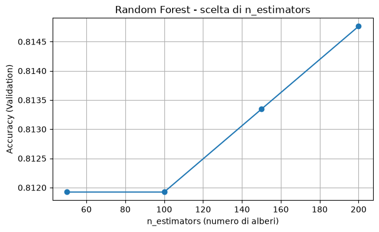

```
               Test Report - Random Forest
                     Accuracy: 0.8020
┏━━━━━━━━━━━━━━┳━━━━━━━━━━━┳━━━━━━━━┳━━━━━━━━━━┳━━━━━━━━━┓
┃ Class        ┃ Precision ┃ Recall ┃ F1-Score ┃ Support ┃
┡━━━━━━━━━━━━━━╇━━━━━━━━━━━╇━━━━━━━━╇━━━━━━━━━━╇━━━━━━━━━┩
│ No Churn     │  0.8436   │ 0.8966 │  0.8693  │  1035   │
│ Yes Churn    │  0.6537   │ 0.5401 │  0.5915  │   374   │
│ macro avg    │  0.7487   │ 0.7184 │  0.7304  │  1409   │
│ weighted avg │  0.7932   │ 0.8020 │  0.7956  │  1409   │
└──────────────┴───────────┴────────┴──────────┴─────────┘
```

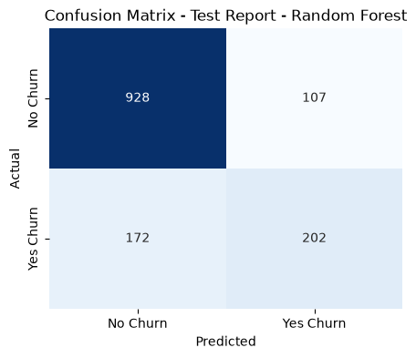

```python
rf, rf_params, rf_val, rf_table = tune_on_validation(
    RandomForestClassifier(random_state=43, n_jobs=-1),
    {'n_estimators': [50, 100, 150, 200], 'max_depth': [None, 10, 20], 'min_samples_leaf': [1, 2, 5]},
)

# Accuracy sul validation al variare di n_estimators (migliore combinazione degli altri parametri)
rf_table.groupby('n_estimators')['validation'].max().plot(marker='o', grid=True, figsize=(7, 4))
plt.xlabel('n_estimators (numero di alberi)')
plt.ylabel('Accuracy (Validation)')
plt.title('Random Forest - scelta di n_estimators')
plt.show()

evaluate_on_test('Random Forest', rf, rf_params)
```

**Random Forest**: iperparametri scelti sul validation `{'max_depth': None, 'min_samples_leaf': 2, 'n_estimators': 200}`. Accuracy 81.5% sul validation e 80.2% sul test (-1.3 punti); precision 0.65, recall 0.54, F1 0.59. Il test è più basso del validation di oltre un punto; con circa 1400 esempi per insieme l'errore standard dell'accuracy è di circa un punto, quindi la differenza è compatibile con la variabilità dello split.

## Bayesian Classifier

Si procede con l'addestramento del secondo modello basato su classificatori Bayesiani

```
Migliori iperparametri (validation): {'var_smoothing': 1e-09}  ->  0.7502
```

```
                Test Report - Naive Bayes
                     Accuracy: 0.7388
┏━━━━━━━━━━━━━━┳━━━━━━━━━━━┳━━━━━━━━┳━━━━━━━━━━┳━━━━━━━━━┓
┃ Class        ┃ Precision ┃ Recall ┃ F1-Score ┃ Support ┃
┡━━━━━━━━━━━━━━╇━━━━━━━━━━━╇━━━━━━━━╇━━━━━━━━━━╇━━━━━━━━━┩
│ No Churn     │  0.8975   │ 0.7275 │  0.8036  │  1035   │
│ Yes Churn    │  0.5053   │ 0.7701 │  0.6102  │   374   │
│ macro avg    │  0.7014   │ 0.7488 │  0.7069  │  1409   │
│ weighted avg │  0.7934   │ 0.7388 │  0.7523  │  1409   │
└──────────────┴───────────┴────────┴──────────┴─────────┘
```

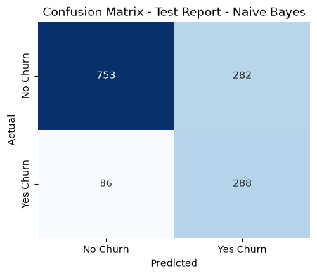

```python
nb_model, nb_params, nb_val, nb_table = tune_on_validation(
    GaussianNB(), {'var_smoothing': [float(v) for v in np.logspace(-9, -1, 9)]}
)
evaluate_on_test('Naive Bayes', nb_model, nb_params)
```

**Naive Bayes**: iperparametri scelti sul validation `{'var_smoothing': 1e-09}`. Accuracy 75.0% sul validation e 73.9% sul test (-1.1 punti); precision 0.51, recall 0.77, F1 0.61. Il test è più basso del validation di oltre un punto; con circa 1400 esempi per insieme l'errore standard dell'accuracy è di circa un punto, quindi la differenza è compatibile con la variabilità dello split. La recall sulla classe churn è alta, a scapito della precision.

## Support Vector Machine

Ci aspettiamo che la sparsità del dataset possa essere penalizzante per il corretto funzionamento dei Support Vectors, pertanto sceglieremo con cura i migliori iperparametri da usare su questo dataset.

Per ogni kernel scegliamo sul validation il parametro `C` (peso degli errori) e, dove serve, `gamma`, il grado del polinomio e il peso delle classi. Le feature vengono standardizzate in una pipeline (lo `StandardScaler` è calcolato sul solo train).

```
=== SVM Linear
Migliori iperparametri (validation): {'linearsvc__C': 0.01, 'linearsvc__class_weight': None}  ->  0.8091
```

```
                 Test Report - SVM Linear
                     Accuracy: 0.8070
┏━━━━━━━━━━━━━━┳━━━━━━━━━━━┳━━━━━━━━┳━━━━━━━━━━┳━━━━━━━━━┓
┃ Class        ┃ Precision ┃ Recall ┃ F1-Score ┃ Support ┃
┡━━━━━━━━━━━━━━╇━━━━━━━━━━━╇━━━━━━━━╇━━━━━━━━━━╇━━━━━━━━━┩
│ No Churn     │  0.8562   │ 0.8860 │  0.8708  │  1035   │
│ Yes Churn    │  0.6509   │ 0.5882 │  0.6180  │   374   │
│ macro avg    │  0.7535   │ 0.7371 │  0.7444  │  1409   │
│ weighted avg │  0.8017   │ 0.8070 │  0.8037  │  1409   │
└──────────────┴───────────┴────────┴──────────┴─────────┘
```

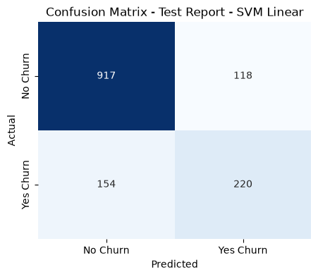

```
=== SVM Poly
```

```
Migliori iperparametri (validation): {'svc__C': 1, 'svc__class_weight': None, 'svc__degree': 3}  ->  0.8062
```

```
                  Test Report - SVM Poly
                     Accuracy: 0.8091
┏━━━━━━━━━━━━━━┳━━━━━━━━━━━┳━━━━━━━━┳━━━━━━━━━━┳━━━━━━━━━┓
┃ Class        ┃ Precision ┃ Recall ┃ F1-Score ┃ Support ┃
┡━━━━━━━━━━━━━━╇━━━━━━━━━━━╇━━━━━━━━╇━━━━━━━━━━╇━━━━━━━━━┩
│ No Churn     │  0.8450   │ 0.9063 │  0.8746  │  1035   │
│ Yes Churn    │  0.6756   │ 0.5401 │  0.6003  │   374   │
│ macro avg    │  0.7603   │ 0.7232 │  0.7374  │  1409   │
│ weighted avg │  0.8001   │ 0.8091 │  0.8018  │  1409   │
└──────────────┴───────────┴────────┴──────────┴─────────┘
```

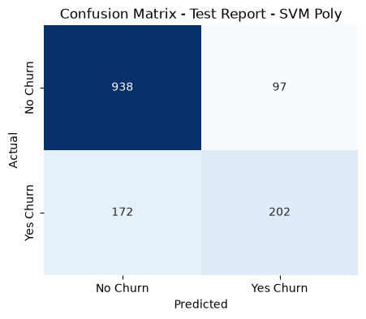

```
=== SVM RBF
```

```
Migliori iperparametri (validation): {'svc__C': 100, 'svc__class_weight': None, 'svc__gamma': 0.01}  ->  0.8126
```

```
                  Test Report - SVM RBF
                     Accuracy: 0.7963
┏━━━━━━━━━━━━━━┳━━━━━━━━━━━┳━━━━━━━━┳━━━━━━━━━━┳━━━━━━━━━┓
┃ Class        ┃ Precision ┃ Recall ┃ F1-Score ┃ Support ┃
┡━━━━━━━━━━━━━━╇━━━━━━━━━━━╇━━━━━━━━╇━━━━━━━━━━╇━━━━━━━━━┩
│ No Churn     │  0.8562   │ 0.8686 │  0.8624  │  1035   │
│ Yes Churn    │  0.6212   │ 0.5963 │  0.6085  │   374   │
│ macro avg    │  0.7387   │ 0.7324 │  0.7354  │  1409   │
│ weighted avg │  0.7938   │ 0.7963 │  0.7950  │  1409   │
└──────────────┴───────────┴────────┴──────────┴─────────┘
```

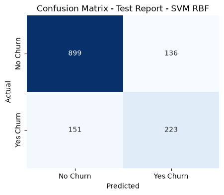

```
=== SVM Sigmoid
```

```
Migliori iperparametri (validation): {'svc__C': 10, 'svc__class_weight': None, 'svc__gamma': 0.01}  ->  0.8077
```

```
                Test Report - SVM Sigmoid
                     Accuracy: 0.8105
┏━━━━━━━━━━━━━━┳━━━━━━━━━━━┳━━━━━━━━┳━━━━━━━━━━┳━━━━━━━━━┓
┃ Class        ┃ Precision ┃ Recall ┃ F1-Score ┃ Support ┃
┡━━━━━━━━━━━━━━╇━━━━━━━━━━━╇━━━━━━━━╇━━━━━━━━━━╇━━━━━━━━━┩
│ No Churn     │  0.8609   │ 0.8850 │  0.8728  │  1035   │
│ Yes Churn    │  0.6551   │ 0.6043 │  0.6287  │   374   │
│ macro avg    │  0.7580   │ 0.7447 │  0.7507  │  1409   │
│ weighted avg │  0.8063   │ 0.8105 │  0.8080  │  1409   │
└──────────────┴───────────┴────────┴──────────┴─────────┘
```

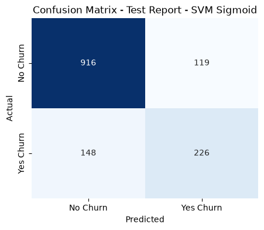

```python
svm_specs = {
    'SVM Linear': (make_pipeline(StandardScaler(), LinearSVC(max_iter=20000, random_state=42)),
                   {'linearsvc__C': [0.01, 0.1, 1, 10, 100], 'linearsvc__class_weight': [None, 'balanced']}),
    'SVM Poly': (make_pipeline(StandardScaler(), SVC(kernel='poly', random_state=42)),
                 {'svc__C': [0.1, 1, 10], 'svc__degree': [2, 3], 'svc__class_weight': [None, 'balanced']}),
    'SVM RBF': (make_pipeline(StandardScaler(), SVC(kernel='rbf', random_state=42)),
                {'svc__C': [0.1, 1, 10, 100], 'svc__gamma': ['scale', 0.001, 0.01], 'svc__class_weight': [None, 'balanced']}),
    'SVM Sigmoid': (make_pipeline(StandardScaler(), SVC(kernel='sigmoid', random_state=42)),
                    {'svc__C': [0.1, 1, 10], 'svc__gamma': ['scale', 0.001, 0.01], 'svc__class_weight': [None, 'balanced']}),
}
svm_tables = {}
for name, (pipe, grid) in svm_specs.items():
    print(f"\n=== {name}")
    model, params, _, svm_tables[name] = tune_on_validation(pipe, grid)
    evaluate_on_test(name, model, params)
```

- **SVM Linear**: iperparametri scelti sul validation `{'C': 0.01, 'class_weight': None}`. Accuracy 80.9% sul validation e 80.7% sul test (-0.2 punti); precision 0.65, recall 0.59, F1 0.62. Validation e test coincidono entro un punto.
- **SVM Poly**: iperparametri scelti sul validation `{'C': 1, 'class_weight': None, 'degree': 3}`. Accuracy 80.6% sul validation e 80.9% sul test (+0.3 punti); precision 0.68, recall 0.54, F1 0.60. Validation e test coincidono entro un punto.
- **SVM RBF**: iperparametri scelti sul validation `{'C': 100, 'class_weight': None, 'gamma': 0.01}`. Accuracy 81.3% sul validation e 79.6% sul test (-1.6 punti); precision 0.62, recall 0.60, F1 0.61. Il test è più basso del validation di oltre un punto; con circa 1400 esempi per insieme l'errore standard dell'accuracy è di circa un punto, quindi la differenza è compatibile con la variabilità dello split.
- **SVM Sigmoid**: iperparametri scelti sul validation `{'C': 10, 'class_weight': None, 'gamma': 0.01}`. Accuracy 80.8% sul validation e 81.0% sul test (+0.3 punti); precision 0.66, recall 0.60, F1 0.63. Validation e test coincidono entro un punto.

## RETI-NEURALI

Per il classificatore MLP (Multilayer Perceptron) si cercano sul validation numero di neuroni, funzione di attivazione e regolarizzazione `alpha`. I dati sono standardizzati in una pipeline; solver `adam`, al massimo 1000 iterazioni.

```
Migliori iperparametri (validation): {'mlpclassifier__activation': 'relu', 'mlpclassifier__alpha': 0.01, 'mlpclassifier__hidden_layer_sizes': (10, 5)}  ->  0.8126
```

```
                    Test Report - MLP
                     Accuracy: 0.7942
┏━━━━━━━━━━━━━━┳━━━━━━━━━━━┳━━━━━━━━┳━━━━━━━━━━┳━━━━━━━━━┓
┃ Class        ┃ Precision ┃ Recall ┃ F1-Score ┃ Support ┃
┡━━━━━━━━━━━━━━╇━━━━━━━━━━━╇━━━━━━━━╇━━━━━━━━━━╇━━━━━━━━━┩
│ No Churn     │  0.8538   │ 0.8686 │  0.8611  │  1035   │
│ Yes Churn    │  0.6180   │ 0.5882 │  0.6027  │   374   │
│ macro avg    │  0.7359   │ 0.7284 │  0.7319  │  1409   │
│ weighted avg │  0.7912   │ 0.7942 │  0.7925  │  1409   │
└──────────────┴───────────┴────────┴──────────┴─────────┘
```

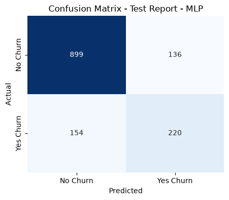

```python
mlp, mlp_params, mlp_val, mlp_table = tune_on_validation(
    make_pipeline(StandardScaler(), MLPClassifier(solver='adam', max_iter=1000, random_state=42)),
    {'mlpclassifier__hidden_layer_sizes': [(10,), (20,), (30,), (10, 5), (20, 10), (30, 15)],
     'mlpclassifier__activation': ['relu', 'tanh', 'logistic'],
     'mlpclassifier__alpha': [1e-4, 1e-2]},
)
evaluate_on_test('MLP', mlp, mlp_params)
```

**MLP**: iperparametri scelti sul validation `{'activation': 'relu', 'alpha': 0.01, 'hidden_layer_sizes': (10, 5)}`. Accuracy 81.3% sul validation e 79.4% sul test (-1.8 punti); precision 0.62, recall 0.59, F1 0.60. Il test è più basso del validation di oltre un punto; con circa 1400 esempi per insieme l'errore standard dell'accuracy è di circa un punto, quindi la differenza è compatibile con la variabilità dello split.

# **Confronto dei modelli di classificazione**

Il confronto si fa sul **test set**, che non ha influenzato nessuna scelta. L'accuracy sul validation è riportata solo per mostrare quanto la stima fatta durante la scelta degli iperparametri si discosti da quella sul test.

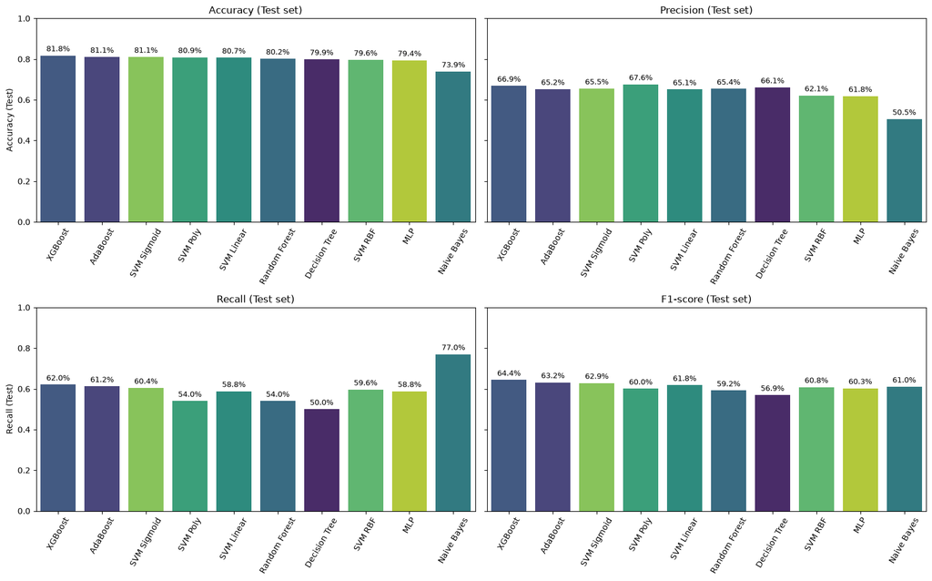

```python
results_df = pd.DataFrame(original_results)

fig, axes = plt.subplots(2, 2, figsize=(16, 10), sharey=True)
order = results_df.sort_values('Accuracy (Test)', ascending=False)['Algorithm']
for ax, metric in zip(axes.ravel(), ['Accuracy', 'Precision', 'Recall', 'F1-score']):
    sns.barplot(data=results_df, x='Algorithm', y=f'{metric} (Test)', order=order, ax=ax, hue='Algorithm', palette='viridis', legend=False)
    ax.set_title(f'{metric} (Test set)')
    ax.set_ylim(0, 1)
    ax.set_xlabel('')
    ax.tick_params(axis='x', rotation=60)
    for p in ax.patches:
        ax.annotate(f"{p.get_height() * 100:.1f}%", (p.get_x() + p.get_width() / 2, p.get_height()),
                    ha='center', va='bottom', fontsize=9, xytext=(0, 3), textcoords='offset points')
plt.tight_layout()
plt.show()
```

```python
summary = Table(title="Confronto modelli (ordinati per accuracy sul test)", expand=True)
for col in ["Algorithm", "Acc (Val)", "Acc (Test)", "Prec (Test)", "Rec (Test)", "F1 (Test)"]:
    summary.add_column(col, justify="left" if col == "Algorithm" else "right")
for r in sorted(original_results, key=lambda r: r['Accuracy (Test)'], reverse=True):
    summary.add_row(r['Algorithm'], f"{r['Accuracy (Validation)']:.4f}", f"{r['Accuracy (Test)']:.4f}",
                    f"{r['Precision (Test)']:.4f}", f"{r['Recall (Test)']:.4f}", f"{r['F1-score (Test)']:.4f}")
console.print(summary)
```

```
                                Confronto modelli (ordinati per accuracy sul test)
┏━━━━━━━━━━━━━━━━━━━━━━┳━━━━━━━━━━━━━━━━━┳━━━━━━━━━━━━━━━━━━┳━━━━━━━━━━━━━━━━━━━┳━━━━━━━━━━━━━━━━━┳━━━━━━━━━━━━━━━┓
┃ Algorithm            ┃       Acc (Val) ┃       Acc (Test) ┃       Prec (Test) ┃      Rec (Test) ┃     F1 (Test) ┃
┡━━━━━━━━━━━━━━━━━━━━━━╇━━━━━━━━━━━━━━━━━╇━━━━━━━━━━━━━━━━━━╇━━━━━━━━━━━━━━━━━━━╇━━━━━━━━━━━━━━━━━╇━━━━━━━━━━━━━━━┩
│ XGBoost              │          0.8268 │           0.8176 │            0.6686 │          0.6203 │        0.6436 │
│ AdaBoost             │          0.8204 │           0.8105 │            0.6524 │          0.6123 │        0.6317 │
│ SVM Sigmoid          │          0.8077 │           0.8105 │            0.6551 │          0.6043 │        0.6287 │
│ SVM Poly             │          0.8062 │           0.8091 │            0.6756 │          0.5401 │        0.6003 │
│ SVM Linear           │          0.8091 │           0.8070 │            0.6509 │          0.5882 │        0.6180 │
│ Random Forest        │          0.8148 │           0.8020 │            0.6537 │          0.5401 │        0.5915 │
│ Decision Tree        │          0.8098 │           0.7991 │            0.6608 │          0.5000 │        0.5693 │
│ SVM RBF              │          0.8126 │           0.7963 │            0.6212 │          0.5963 │        0.6085 │
│ MLP                  │          0.8126 │           0.7942 │            0.6180 │          0.5882 │        0.6027 │
│ Naive Bayes          │          0.7502 │           0.7388 │            0.5053 │          0.7701 │        0.6102 │
└──────────────────────┴─────────────────┴──────────────────┴───────────────────┴─────────────────┴───────────────┘
```

## Conclusioni

Tutte le scelte degli iperparametri sono state fatte sul validation set; il test set è stato usato una volta per modello, quindi i numeri sotto sono stime non distorte dalla selezione.

- **Migliori per accuracy sul test**: XGBoost (81.8%, F1 0.64), AdaBoost (81.0%, F1 0.63), SVM Sigmoid (81.0%, F1 0.63).
- **Miglior F1 sul test**: XGBoost (0.64); **miglior recall**: Naive Bayes (0.77, con precision 0.51).
- **Peggiore**: Naive Bayes (73.9% di accuracy sul test).
- Il 26,5% dei clienti fa churn, quindi predire sempre "nessun churn" darebbe circa il 73,5% di accuracy: l'accuracy va letta insieme a recall e F1 sulla classe churn.
- Escludendo il peggiore, i modelli stanno in circa 2.3 punti di accuracy sul test: differenze così piccole non permettono di dichiarare un vincitore netto con un solo split. Per distinguerli servirebbero una cross-validation ripetuta o più split.